# Nuclear Power, miracle or menace?

## Preamble

**Nuclear energy** emerged out of atomic science advancements during WWII and enjoyed several decades of significant expansion to address industrializing nations’ energy demands.  
Nuclear energy appeared limitless in its potential, sparking imaginations everywhere.

## Deepening into the analysis

Let’s track the growth of nuclear power as a source of global energy generation since the 1960s.

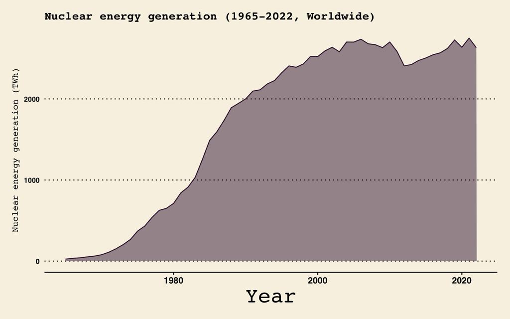

Today, worldwide the nuclear energy is providing about 10% of global electricity generation.  
In Europe, Nuclear power plants generated around 21.8% of the total electricity produced in 2022.

Fossil fuels like coal, oil, and brown coal generally have higher death rates due to factors like air pollution from emissions and accidents during mining and extraction.

Renewable energy sources like solar, wind, and hydropower have significantly lower death rates.

**What about nuclear energy?**

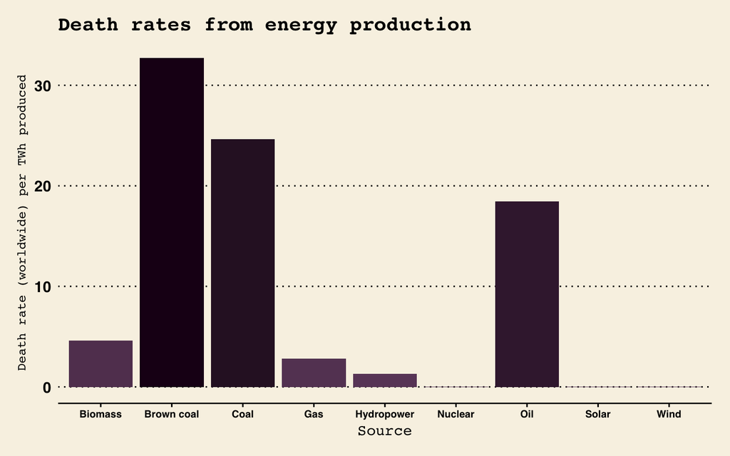

We should change the chart’s scale…

The value of 0.03 for nuclear is low… and incorrect; it should be even smaller.

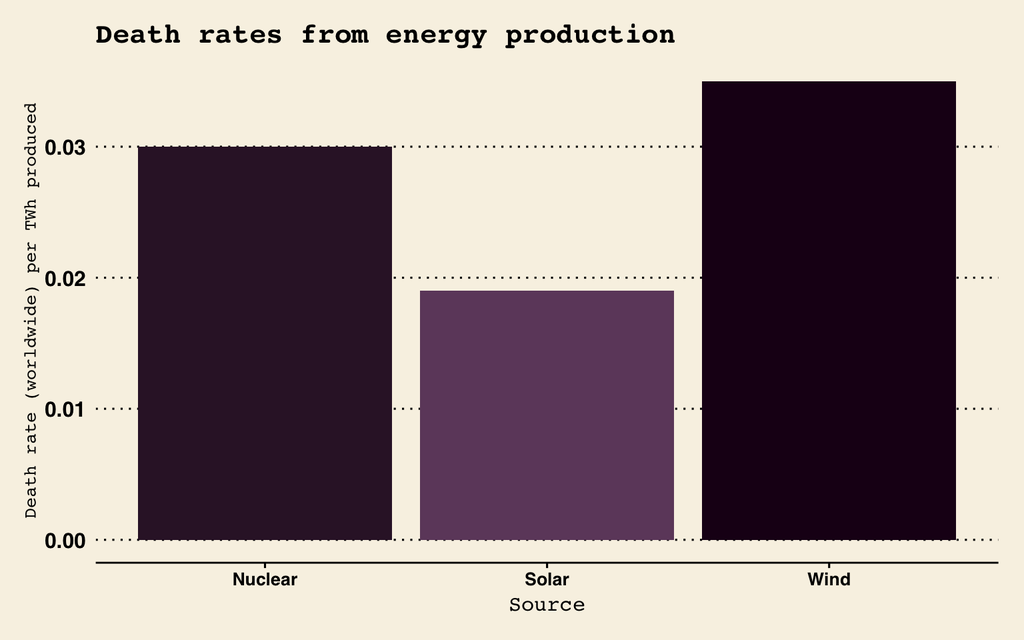

## France vs Germany approach.

**France:**  
Relies heavily on nuclear energy, which provides around 70% of its electricity, one of the highest rates in the world. Invested massively in nuclear after the 1970s oil crisis to reduce dependence on foreign fossil fuels. Nuclear is considered a stable, low-carbon source that supports climate goals without emissions.

**Germany:**  
Took the decision to phase out all nuclear power by 2022 following the Fukushima disaster in Japan. This was part of an “energiewende” or energy transition plan to shift completely to renewable sources. Germany has invested heavily in solar and wind.

There is a consistent disparity in the carbon intensity of electricity generation between Germany and France throughout 2023. Notably, Germany’s electricity production exhibited a higher carbon footprint compared to France.

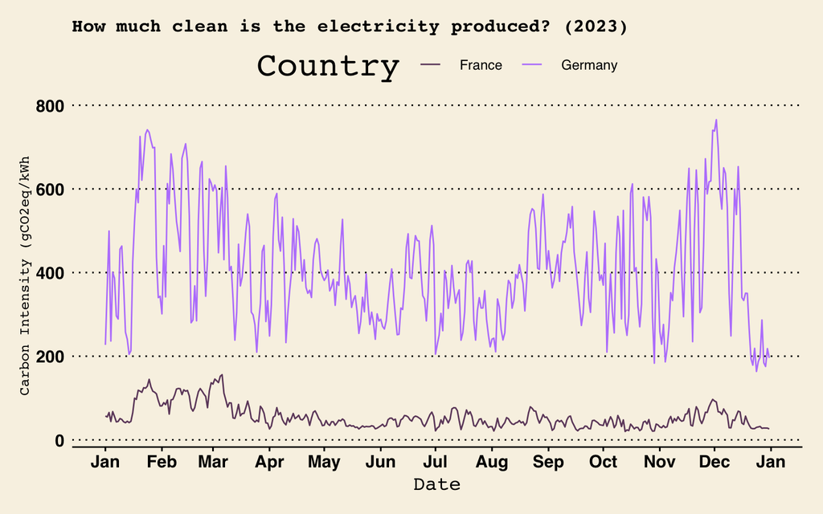

Despite surpassing France in the total amount of electricity generated from renewable energy sources (REN), Germany still exhibited a higher carbon intensity in its overall electricity production.  
**why?**

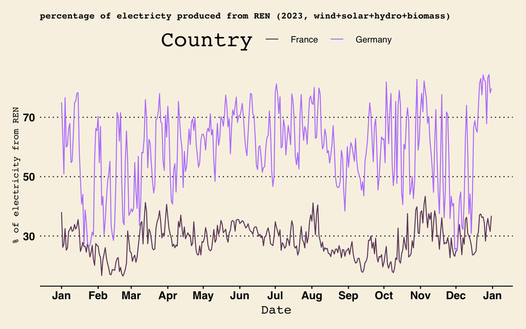

It is evident that France consistently exhibits a **lower carbon footprint** for its electricity production compared to Germany. This suggests a potential advantage for France in terms of contributing to climate change mitigation efforts.

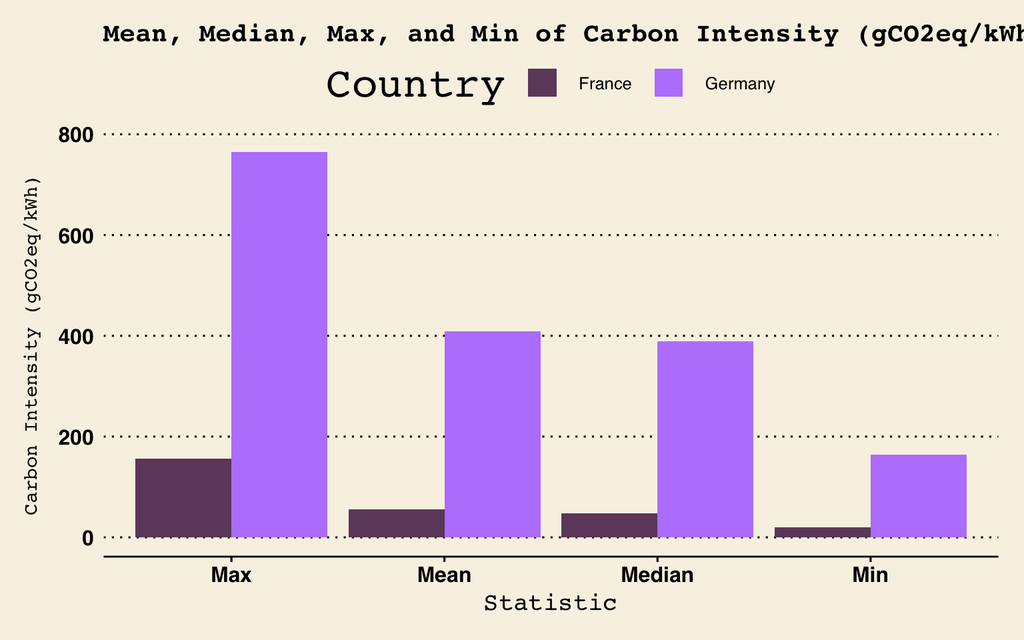

The observed disparity in carbon intensity between France and Germany can be partly explained by their differing energy mixes. Notably, despite significant investments in renewable energy sources, **Germany still relied heavily on coal in 2023**, accounting for 32% of its energy mix.

**France average energy mix**

[interactive chart not shown]

**German average energy mix**

[interactive chart not shown]

## Network science

This study looks at how electricity flows across Europe using a technique called “network science”. Network science allows us to represent this flow as a network and learn from its structure. By analyzing the European electricity network, it’s possible to focus on the centrality and power of this grid.

The directed graph depicts the interconnection network for sharing electricity across European countries in a specific date and time.

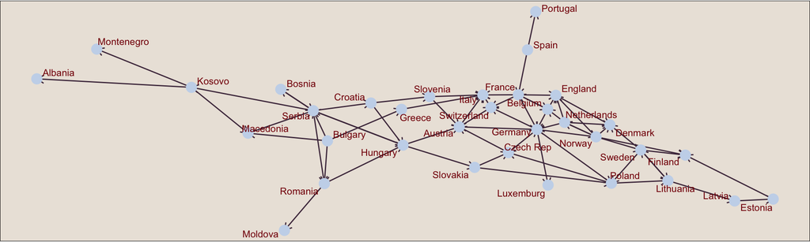

The network reveals a highly meshed infrastructure with numerous connections that allow countries to import and export electricity as needed to balance domestic supply and demand.

## Community Detection

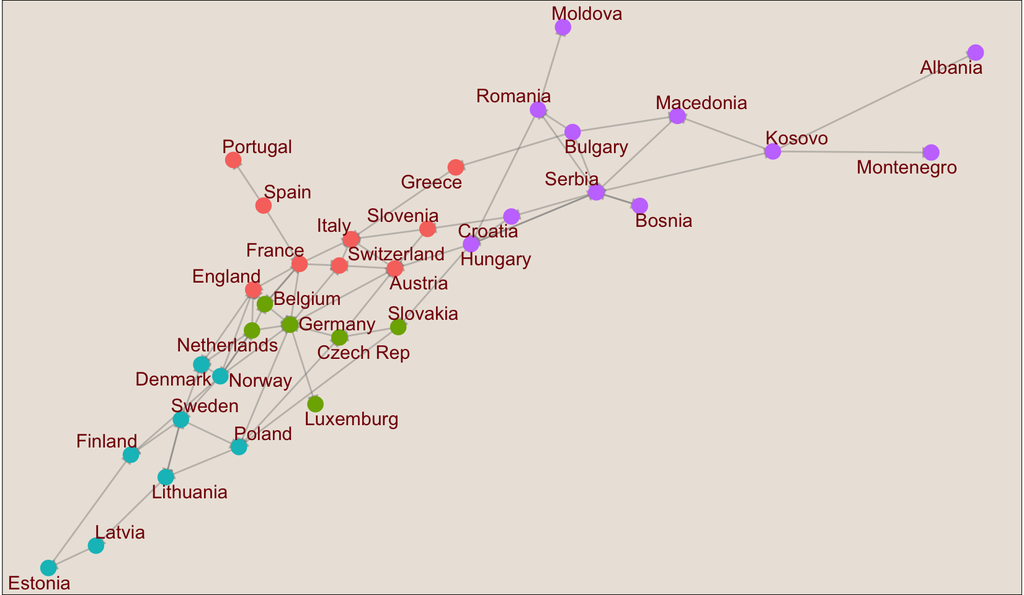

Modularity Scores for Different Community Detection Algorithms

| Algorithm | Modularity Score |
| --- | --- |
| Optimal | 0.5136 |
| Leading Eigenvector | 0.4958 |
| Walktrap | 0.4701 |
| Label Propagation | 0.4461 |
| Edge Betweenness | 0.3645 |
| Infomap | 0.1159 |
| Spinglass | 0.0007 |

## Global Similarity of the network

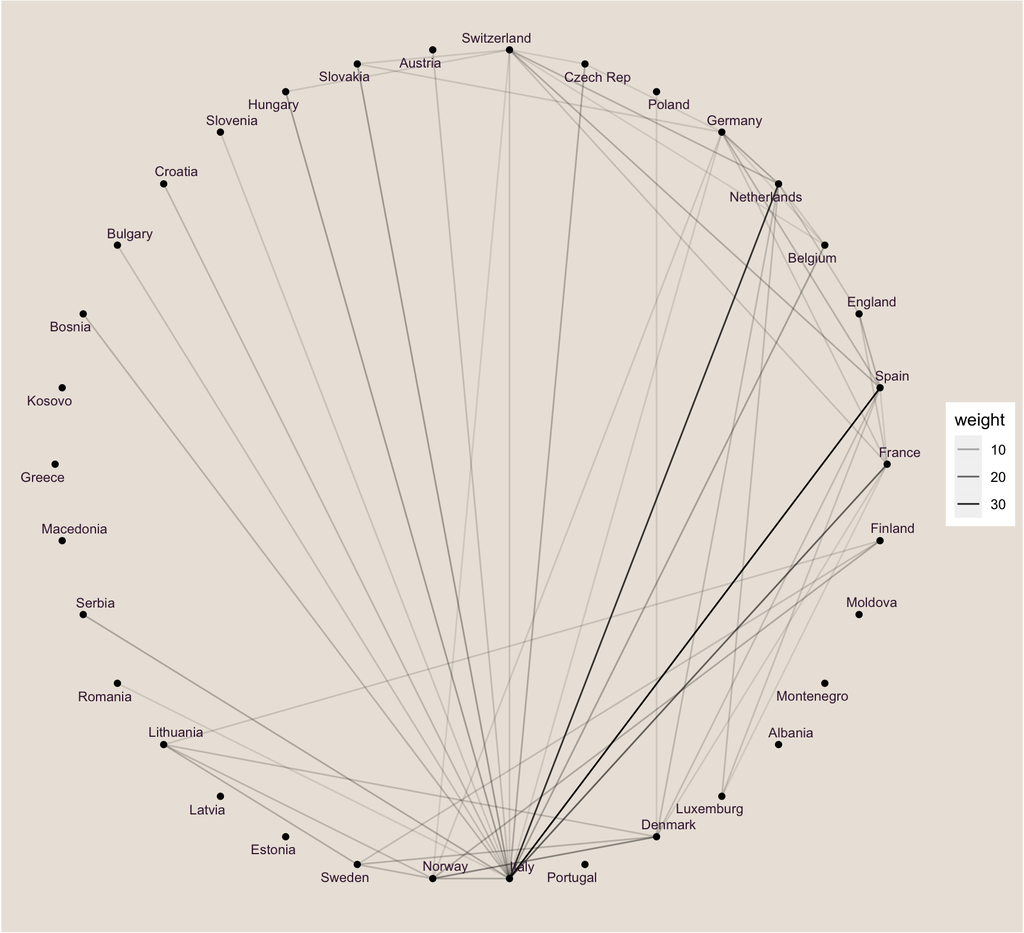

## Katz Centrality & Power of the Network

Networks are made up of nodes (individuals or entities) linked by connections of some kind (in this case, electricity share). In social networks, more central or well-connected nodes tend to have greater influence and power within the network. Their actions can significantly impact others.

Top-5 states according to centrality:

```
##      Norway      France Netherlands      Serbia     Germany
##       5.233       4.361       4.361       4.361       3.489
```

Top-5 states according to power:

```
##      Norway Netherlands      Serbia      France     Bulgary
##        2.36        2.07        1.97        1.87        1.58
```

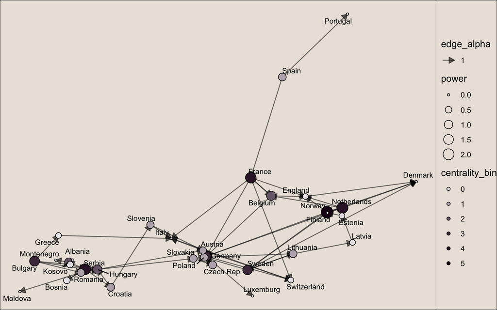

## Percolation process

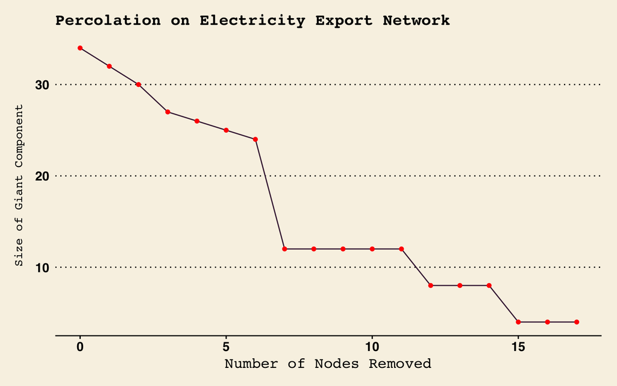

## Conclusions

An examination of reports from leading organizations like the IPCC, IEA, and IAEA highlights a strong rationale for expanding our reliance on nuclear energy as a critical component of the clean energy transition. While achieving a 100% renewable energy system may appear attractive on the surface, it remains an unrealistic and potentially impractical goal for most nations in the near future.